# Linear State Space Model

Answers to the Exercises in the QuantEcon Lecture

經濟學

Author

Yin-Yun Li

Published

January 26, 2026

**TipForeword**

This document contains notes and answers based on the problem sets in the **QuantEcon** lecture: [Linear State Space Models](https://julia.quantecon.org/introduction_dynamics/linear_models.html).

These codes mainly come from the package **QuantEcon.jl**. Some introduction on this page is documented in their fancy pacakge. For more detailed information, please refer to [QuantEcon](https://quantecon.github.io/QuantEcon.jl/latest/index.html) and src/lss.jl.

# Linear State Space Model: Setup

A type that describes the Gaussian Linear State Space Model of the form:

$$\begin{aligned}
x_{t+1} &= A x_t + C w_{t+1} \\
y_t &= G x_t + H v_t
\end{aligned}$$

where $\{w_t\}$ and $\{v_t\}$ are independent and standard normal with dimensions $k$ and $l$ respectively. The initial conditions are $\mu_0$ and $\Sigma_0$ for $x_0 \sim N(\mu_0, \Sigma_0)$. When $\Sigma_0=0$, the draw of $x_0$ is exactly $\mu_0$.

## Objects

- `A::Matrix`: Part of the state transition equation. It should be $n \times n$.
- `C::Matrix`: Part of the state transition equation. It should be $n \times m$.
- `G::Matrix`: Part of the observation equation. It should be $k \times n$.
- `H::Matrix`: Part of the observation equation. It should be $k \times l$.
- `k::Int`: Dimension.
- `n::Int`: Dimension.
- `m::Int`: Dimension.
- `l::Int`: Dimension.
- `mu_0::Vector`: This is the mean of initial draw and is of length $n$.
- `Sigma_0::Matrix`: This is the variance of the initial draw and is $n \times n$ and also should be positive definite and symmetric.

Define all the objects we require:

```julia
using QuantEcon, LinearAlgebra, Statistics, Distributions, Plots, LaTeXStrings, Random, StatsPlots

const ScalarOrArray = Union{Number, AbstractArray}

mutable struct LSS{TSampler<:MVNSampler}
    A::Matrix
    C::Matrix
    G::Matrix
    H::Matrix
    k::Int
    n::Int
    m::Int
    l::Int
    mu_0::Vector
    Sigma_0::Matrix
    dist::TSampler
end;

function LSS(A::ScalarOrArray, C::ScalarOrArray, G::ScalarOrArray, H::ScalarOrArray,
             mu_0::ScalarOrArray,
             Sigma_0::Matrix=zeros(size(G, 2), size(G, 2)))
    k = size(G, 1)
    n = size(G, 2)
    m = size(C, 2)
    l = size(H, 2)

    # coerce shapes
    A = reshape(vcat(A), n, n)
    C = reshape(vcat(C), n, m)
    G = reshape(vcat(G), k, n)
    H = reshape(vcat(H), k, l)

    mu_0 = reshape([mu_0;], n)

    dist = MVNSampler(mu_0,Sigma_0)
    LSS(A, C, G, H, k, n, m, l, mu_0, Sigma_0, dist)
end;

# make kwarg version; user input
function LSS(A::ScalarOrArray, C::ScalarOrArray, G::ScalarOrArray;
             H::ScalarOrArray=zeros(size(G, 1)),
             mu_0::Vector=zeros(size(G, 2)),
             Sigma_0::Matrix=zeros(size(G, 2), size(G, 2)))
    return LSS(A, C, G, H, mu_0, Sigma_0)
end;
```

## Data Generating Process

```julia
function simulate(lss::LSS, ts_length=100)
    x = Matrix{Float64}(undef, lss.n, ts_length)
    x[:, 1] = rand(lss.dist)
    w = randn(lss.m, ts_length - 1)
    v = randn(lss.l, ts_length)
    for t=1:ts_length-1
        x[:, t+1] = lss.A * x[:, t] .+ lss.C * w[:, t]
    end
    y = lss.G * x + lss.H * v

    return x, y
end;
```

# Exercises

## Exercise 1

Consider a second order difference equation:
$$y_{t+1} = \phi_0 + \phi_1 y_t + \phi_2 y_{t-1}
\quad \text{s.t.} \quad
y_0, y_{-1} \text{ given}$$

We aim to simulate the deterministic sequence $\{y_t\}_{t\in T}$ (See Figure 1)

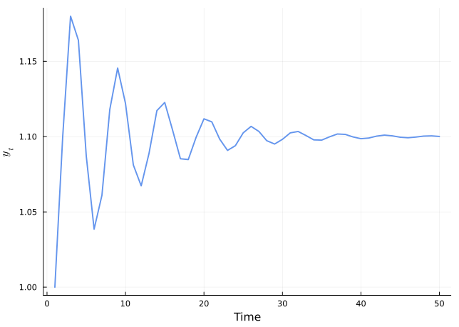

Figure 1: Second Order Difference Equation: Simulated Path

```julia
SODE = LSS([1 0 0; 1.1 0.8 -0.8; 0 1 0], # A
           [0.0 0.0 0.0]', # C
           [0.0 1.0 0.0];  # G
           mu_0 = ones(3))
x,y = simulate(SODE, 50);

plot(vec(y),
     color = :cornflowerblue,
     linewidth = 2,
     title = "",
     titlefontsize = 10,
     xlabel = "Time", ylabel = L"y_t", legend = false)
```

## Exercise 2

Consider the following univariate autoregressive process:
$$y_{t+1} = \phi_1 y_{t} + \phi_2 y_{t-1} + \phi_3 y_{t-2} + \phi_4 y_{t-3} + \sigma w_{t+1}$$

The dynamic pattern of $\{y_t\}_{t\in T}$ is illustrated in Figure 2:

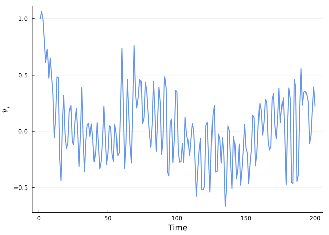

Figure 2: Univariate Autoregressive Processes: Simulated Path of Observations

```julia
𝝓_1, 𝝓_2, 𝝓_3, 𝝓_4 = 0.5, -0.2, 0.0, 0.5
σ = 0.2
UVA = LSS([𝝓_1 𝝓_2 𝝓_3 𝝓_4;
            1 0 0 0;
            0 1 0 0;
            0 0 1 0], # A
           [σ 0.0 0.0 0.0]', # C
           [1.0 0.0 0.0 0.0];  # G
           mu_0 = ones(4))
x,y = simulate(UVA, 200);

plot(vec(y),
     color = :cornflowerblue,
     linewidth = 2,
     title = "",
     titlefontsize = 10,
     xlabel = "Time", ylabel = L"y_t", legend = false)
```

## Exercise 3

Based on the previous exercise, now we want to compute the ensemble average and longrun average (See Figure 3).

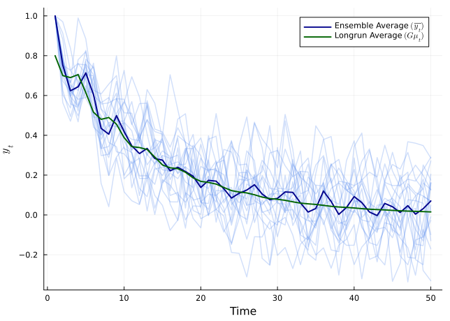

Figure 3: Ensemble Average v.s. Longrun Average

```julia
T, I = 50, 20
rep_matrix = zeros(T, I)
tran_vec = zeros(T)
σ = 0.1
A = [𝝓_1 𝝓_2 𝝓_3 𝝓_4
       1 0 0 0
       0 1 0 0
       0 0 1 0]
G = [1.0 0.0 0.0 0.0]
μ_0 = ones(4)
uva = LSS(A, [σ 0.0 0.0 0.0]', G; mu_0 = μ_0)

### Ensemble Average
for i in 1:I
    res = simulate(uva, T)
    rep_matrix[:,i] =  res[2]
end

### Longrun Average
μt = μ_0
for t in 1:T
    μt_prime = A*μt
    tran_vec[t] = only(G*μt_prime)
    μt = μt_prime
end

plot(rep_matrix,
     color = :cornflowerblue,
     alpha = 0.3,
     linewidth = 1.5,
     label = "",
     title = "",
     xlabel = "Time",
     ylabel = L"y_t",
     legend = :topright
)

ensemble_avg = mean(rep_matrix, dims=2)

plot!(ensemble_avg,
      color = :darkblue,
      linewidth = 2,
      label = "Ensemble Average " * L"(\overline{y_t})",
)


plot!(tran_vec,
      color = :darkgreen,
      linewidth = 2,
      label = "Longrun Average " * L"(G \mu_t)"
)
```

## Exercise 4

**Note`moment_sequence(lss)`**

Create an iterator to calculate the population mean and variance-covariance matrix for both $x_t$ and $y_t$, starting at the initial condition `(self.mu_0, self.Sigma_0)`. Each iteration produces a 4-tuple of items `(mu_x, mu_y, Sigma_x, Sigma_y)` for the next period.

**Arguments**

- `lss::LSS`: An instance of the Gaussian linear state space model.

**Returns**

- `iterator`: An iterator that yields 4-tuples `(mu_x, mu_y, Sigma_x, Sigma_y)` for each period.

*Source: [QuantEcon.jl API](https://quantecon.github.io/QuantEcon.jl/latest/api/QuantEcon.html#QuantEcon.moment_sequence-Tuple%7BLSS%7D)*

**Note`stationary_distributions(lss; max_iter, tol)`**

Compute the moments of the stationary distributions of $x_t$ and $y_t$ if possible. Computation is by iteration, starting from the initial conditions `lss.mu_0` and `lss.Sigma_0`.

**Arguments**

- `lss::LSS`: An instance of the Gaussian linear state space model.
- `;max_iter::Int = 200`: The maximum number of iterations allowed.
- `;tol::Float64 = 1e-5`: The tolerance level one wishes to achieve.

**Returns**

- `mu_x::Vector`: Represents the stationary mean of $x_t$.
- `mu_y::Vector`: Represents the stationary mean of $y_t$.
- `Sigma_x::Matrix`: Represents the var-cov matrix.
- `Sigma_y::Matrix`: Represents the var-cov matrix.

*Source: [QuantEcon.jl API](https://quantecon.github.io/QuantEcon.jl/latest/api/QuantEcon.html#QuantEcon.stationary_distributions-Tuple%7BLSS%7D)*

The result is illustrated in Figure 4

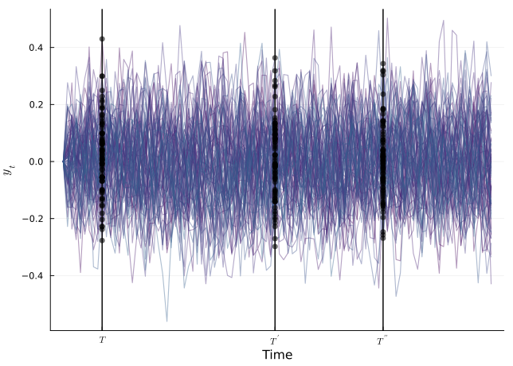

(a) Simulation Dynamic Paths & Cross-sectional Patterns

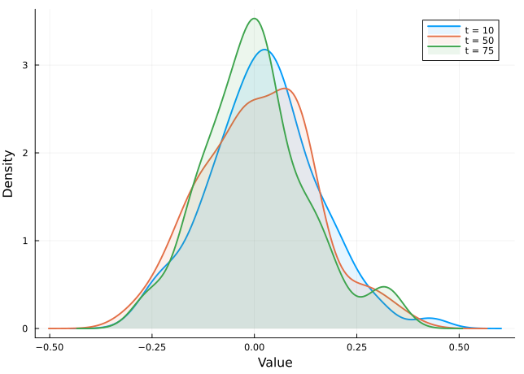

(b) Cross-sectional Distributions Over Time

Figure 4: Verify Stationary Process

```julia
### powerful function from quantecon

struct LSSMoments
    lss::LSS
end

function Base.iterate(L::LSSMoments, state=(copy(L.lss.mu_0),
                                            copy(L.lss.Sigma_0)))
    A, C, G, H = L.lss.A, L.lss.C, L.lss.G, L.lss.H
    mu_x, Sigma_x = state

    mu_y, Sigma_y = G * mu_x, G * Sigma_x * G' + H * H'

    # Update moments of x
    mu_x2 = A * mu_x
    Sigma_x2 = A * Sigma_x * A' + C * C'

    return ((mu_x, mu_y, Sigma_x, Sigma_y), (mu_x2, Sigma_x2))
end

moment_sequence(lss::LSS) = LSSMoments(lss)

function stationary_distributions(lss::LSS; max_iter=200, tol=1e-5)
    !is_stable(lss.A) ? error("Cannot compute stationary distribution because the system is not stable.") : nothing

    # Initialize iteration
    m = moment_sequence(lss)
    mu_x, mu_y, Sigma_x, Sigma_y = first(m)

    i = 0
    err = tol + 1.0

    for (mu_x1, mu_y, Sigma_x1, Sigma_y) in m
        i > max_iter && error("Convergence failed after $i iterations")
        i += 1
        err_mu = maximum(abs, mu_x1 - mu_x)
        err_Sigma = maximum(abs, Sigma_x1 - Sigma_x)
        err = max(err_Sigma, err_mu)
        mu_x, Sigma_x = mu_x1, Sigma_x1

        if err < tol && i > 1
            # return here because of how scoping works in loops.
            return mu_x1, mu_y, Sigma_x1, Sigma_y
        end
    end
end

### begin exercise 4

μx, μy, Σx, Σy = stationary_distributions(uva)
T, I = 100, 80
rep_matrix = zeros(T, I)
σ = 0.1
A = [𝝓_1 𝝓_2 𝝓_3 𝝓_4
       1 0 0 0
       0 1 0 0
       0 0 1 0]
G = [1.0 0.0 0.0 0.0]
stationary_uva = LSS(A, [σ 0.0 0.0 0.0]', G; mu_0 = μx)

for i in 1:I
    res = simulate(stationary_uva, T)
    rep_matrix[:,i] =  res[2]
end


time_points = [10, 50, 75]

p1 = plot(rep_matrix,
    label = "",
    linealpha = 0.4,
    linewidth = 1.2,
    color_palette = :viridis,
    grid = true,
    xlabel = "Time",
    ylabel = L"y_t",
    title = ""
)

vline!(p1, time_points,
    color = :black,
    linewidth = 1.5,
    label = ""
)

for t in time_points

    x_vals = fill(t, I)
    y_vals = rep_matrix[t, :]

    scatter!(p1, x_vals, y_vals,
        color = :black,
        alpha = 0.6,
        markersize = 4,
        markerstrokewidth = 0,
        label = ""
    )
end

xticks!(p1, time_points, [L"T", L"T^\prime", L"T^{\prime\prime}"])

p2 = plot(layout = (1, 3), size = (900, 300), legend = nothing)
p2 = plot(title = "",
         xlabel = "Value",
         ylabel = "Density",
         legend = :topright)

for t in time_points
    data_slice = rep_matrix[t, :]

    density!(p2, data_slice,
             label = "t = $t",
             linewidth = 2,
             fill = (0, 0.1))
end

display(p1)
display(p2)
```